# Assessment of ERA5 data for solar resource mapping

2019-08-22

## Introduction

The project is structured as follows:

- *M* folder containing the RMarkdown source code and HTML and DOCX files converted from Rmd file;
- *RDate* folder where R objects are stored;
- *tabs* folder which contain metadata of the stations and the solar global radiation data extracted from ERA5 model and BSRN network;
- *sh* folder with the ksh scripts run on the ecgate cluster;
- *R* folder with R language script.

## Input dataset

- ERA5 Surface solar radiation downwards [J/m2] hourly accumulate parameter will be used as the main dataset in this work:
- The reference dataset will consist of solar radiation measurements obtained from the Baseline Surface Radiation Network (BSRN - https://bsrn.awi.de/).

### Baseline Surface Radiation Network

- consist of 24 radiometric stations located in in contrasting climatic zones;
- solar and atmospheric radiation measurments;
- equipped with instruments of the highest available accuracy and with high time resolution;
- the BSRN datasets is retrievable via PANGAEA portal (https://bsrn.awi.de/data/data-retrieval-via-pangaea/);
- hourly data from the stations that have observations available between 2006 to 2015 (Figure 1, Table 1);
- were considered only the days which have at least 90 % of available radiation data for each day.

The sub-hourly raw values were averaged to daily values, after they were quality checked using the algorithm Solarpos without refraction as implemented in BSRN Toolbox (Schmithüsen, Sieger, and König-Langlo 2012).

```r
library(mapview)
library(sp)
library(knitr)
rad.network <- read.table("../tabs/rad_network.csv", sep = ";", header = T)
kable(rad.network, caption = rad.meta)
```

Table 1: Metadata of the selected radiometric stations

| id | name | latitude | longitude | elevation | country | continent | kg_class | kg_code |
| --- | --- | --- | --- | --- | --- | --- | --- | --- |
| CAR | Carpentras | 44.08300 | 5.05900 | 100 | France | Europe | Csa | 12 |
| CLH | Chesapeake Light | 36.90500 | 75.71300 | 37 | USA | North America | ET | 31 |
| DAR | Darwin | -12.42500 | 130.89100 | 30 | Australia | Australia | Aw | 4 |
| DRA | Desert Rock | 36.62600 | -116.01800 | 1007 | USA | North America | BWk | 8 |
| BON | Bondville | 40.06667 | -88.36667 | 213 | USA | North America | Cfa | 9 |
| BOS | Boulder | 40.12500 | -105.23700 | 1689 | USA | North America | BSk | 6 |
| BRB | Brasilia | -15.60100 | -47.71300 | 1023 | Brazil | South America | Aw | 4 |
| CAB | Cabauw | 51.97110 | 4.92670 | 0 | The Netherlands | Europe | Cfb | 10 |
| CNR | Cener | 42.81600 | -1.60100 | 471 | Spain | Europe | Cfb | 10 |
| E13 | Southern Great Plains | 36.60500 | -97.48500 | 318 | USA | North America | Cfa | 9 |
| FPE | Fort Peck | 48.31667 | -105.10000 | 634 | USA | North America | BSk | 6 |
| FUA | Fukuoka | 33.58220 | 130.37640 | 3 | Japan | Asia | Cfa | 9 |
| GCR | Goodwin Creek | 34.25470 | -89.87290 | 98 | USA | North America | Cfa | 9 |
| GVN | Georg von Neumayer | -70.65000 | -8.25000 | 42 | Dronning Maud Land | Antarctica | Ocean | 32 |
| KWA | Kwajalein | 8.72000 | 167.73100 | 10 | Marshall Islands | Oceania | Ocean | 32 |
| LER | Lerwick | 60.13891 | -1.18466 | 80 | United_Kingdom | Europe | Cfb | 10 |
| NYA | Ny-?lesund | 78.92500 | 11.93000 | 11 | Spitsbergen | Europe | ET | 31 |
| PAL | Palaiseau, SIRTA Observatory | 48.71300 | 2.20800 | 156 | France | Europe | Cfb | 10 |
| PSU | Rock Springs | 40.72000 | -77.93333 | 376 | USA | North America | Cfb | 10 |
| PTR | Petrolina | -9.06800 | -40.31900 | 387 | Brazil | South America | BSh | 5 |
| SMS | S?o Martinho da Serra | -29.44278 | -53.82305 | 489 | Brazil | South America | Cfa | 9 |
| SPO | South Pole | -89.98300 | -24.79900 | 2800 | South Pole | Antarctica | EF | 30 |
| SYO | Syowa | -69.00500 | 39.58900 | 18 | Cosmonaut Sea | Antarctica | EF | 30 |
| TAT | Tateno | 36.05810 | 140.12580 | 25 | Japan | Asia | Cfa | 9 |

```r
coordinates(rad.network) <- ~longitude + latitude
proj4string(rad.network) <- "+init=epsg:4326"
mapview(rad.network, layer.name = 'Radiometric network')
```

[interactive chart not shown]

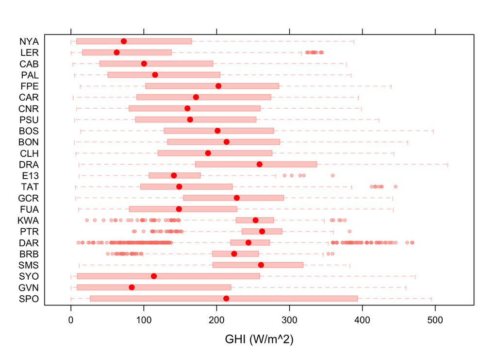

```r
library(lattice)
tab <- read.table("../tabs/rad_network.csv", sep = ";", header = T)
tab <- tab[order(tab$latitude, tab$elevation),]
tabf <- NULL
for (i in 1:nrow(tab)) {

  tab.i <- read.csv(paste0("../tabs/daily_bsrn/", tab$id[i],"_2006_2015.csv"))
  tab.i$id <- tab$id[i]
  tabf <- rbind(tabf, tab.i)
}

tabf$id <- factor(tabf$id, levels = unique(tabf$id))

bwplot(id~ghi, data = tabf, xlab = "GHI (W/m^2)",col = "red",
       par.settings = list(box.rectangle = list(col = "salmon",fill = "salmon",alpha = 0.4),
                           box.umbrella = list(col = "salmon",alpha = 0.4),
                           plot.symbol = list(col = "salmon",alpha = 0.4, pch = 20)))
```

### ERA5 dataset

- the latest global reanalysis product, produced by ECMWF;
- provide hourly meteorological data from 1979 onwards;
- spatial resolution approximate 30 km grid;
- open access and free to download for all uses, including commercial use through the C3S Climate Data Store (https://cds.climate.copernicus.eu);
- more info: https://climate.copernicus.eu/climate-reanalysis.
- two subset used:
- hourly data obtained directly from the ECMWF Meteorological Archival and Retrieval System (MARS), via ecgate cluster;
- monthly data from C3S Climate Data Store.

Due to a large amount of data necessary to be processed at the validation stage, hourly ERA5 data was extracted for the years 2006 to 2015 via ecgate cluster (https://www.ecmwf.int/en/computing/our-facilities/ecgate) by using a retrieve script generated from the links available on the Mars Catalogue:

```
#!/bin/ksh -x
#SBATCH --qos=normal
#SBATCH --job-name=get_era5
#SBATCH --output=/home/ms/ro/roq/scripts/era5/logs/get_era5%N.%j.out
#SBATCH --error=/home/ms/ro/roq/scripts/era5/logs/get_era5%N.%j.out
#SBATCH --workdir=/scratch/ms/ro/roq/radiation
#SBATCH --time=23:30:00

export PATH=$PATH:.
set -xv
cd $SCRATCH/radiation

f_marsReq=marsreq.tmp
f_logMars=marsreq.log

cat >${f_marsReq} <<EOF
retrieve,
class=ea,
date=2005-12-30/to/2016-01-01,
expver=1,
levtype=sfc,
param=169.128,
stream=oper,
time=06:00:00/18:00:00,
type=fc,
step=1/2/3/4/5/6/7/8/9/10/11/12,
grid=0.28125/0.28125,
target="ghi.grb"
EOF
#-- Perform MARS request in one go
export MARS_MULTITARGET_STRICT_FORMAT=1
mars < ${f_marsReq} > ${f_logMars}
```

The hourly data was agggregated to daily data and save as NetCDF file using the Climate Data Operators (CDO - https://www.mpimet.mpg.de/cdo/) tool (Kaspar, Schulzweida, and Muller 2010). CDO was developed at the Max-Planck-Institute for Meteorology. It is open source and released under the terms of the GNU General Public License v2 (GPL). The source code is available at https://code.zmaw.de/projects/cdo.

The computation was performed on the same ecgate cluster.

```
#!/bin/ksh -x
#SBATCH --qos=normal
#SBATCH --job-name=ghi_daily
#SBATCH --output=/home/ms/ro/roq/scripts/era5/logs/to_ghi_daily%N.%j.out
#SBATCH --error=/home/ms/ro/roq/scripts/era5/logs/to_ghi_daily%N.%j.out
#SBATCH --workdir=/scratch/ms/ro/roq/radiation
#SBATCH --time=23:30:00

export PATH=$PATH:.
set -xv

cd $SCRATCH/radiation

module load cdo
cdo setgridtype,regular ghi.grb  output_ghi.grb
cdo -f nc -t ecmwf setgridtype,regular output_ghi.grb output_ghi.nc
rm output_ghi.grb
cdo shifttime,-1hour output_ghi.nc ghi_shift1h.nc
rm output_ghi.nc
cdo daymean ghi_shift1h.nc ghi_daily.nc
rm ghi_shift1h.nc
```

The functions implemented in the CDO tool were used to iteratively extract the daily radiation data at each radiometric station location. The example below shows how the radiation data was obtained from ERA5 at Carpentras radiometric station coordinates:

```
cdo -outputtab,lon,lat,date,time,value -remapnn,lon=5.05900_lat=44.08300 /scratch/ms/ro/roq/radiation/output_ghi.nc > CAR_ERA5.txt
```

## Validation of ERA5 data

The comparison between ERA5 data and reference (BSRN network) dataset was performed for the entire dataset, as well as for the subsets of data by seasons and Köppen-Geiger climate classes, using the well-known indicators of accuracy (bias, root mean squared error, root relative squared error), matrix of scatterplots, the summary statistics (mean, standard deviation, range, etc.). Existing R language tools (e.g. libraries Metrics, openair, etc) were used in analyzing the accuracy of the reanalysis product.

For all the stations, the Köppen-Geiger climate classification metadata was obtained from a high spatial resolution map of 5 arc minutes, representative for the 25-year, period 1986-2010 (Rubel et al. 2017).

The two data sets were merged by using *merge()* function from the R base package, by using field *dates* as common columns. In order to preserve data structures (columns data types), the new dataset was saved as compressed R object:

```r
tab <- read.table("../tabs/rad_network.csv", sep = ";", header = T)

tabf <- NULL
for (i in 1:nrow(tab)) {

  era5 <- read.csv(paste0("../tabs/daily_era5/", tab$id[i], "_2006_2015.csv"))
  era5$date <- as.Date(era5$date)

  bsrn <- read.csv(paste0("../tabs/daily_bsrn/", tab$id[i], "_2006_2015.csv"))
  bsrn$date <- as.Date(as.character(bsrn$date), format = "%Y%m%d")

  tab.i <- merge(era5, bsrn, by.x.y = "date")
  names(tab.i)[3] <- "bsrn_ghi"
  # add id of each station
  tab.i$id <- tab$id[i]
  # add koppen geiger class and code
  tab.i$kg_class <- tab$kg_class[i]
  tab.i$kg_code <- tab$kg_code[i]
  # add hemisphere
  tab.i$hemisphere <- ifelse(tab$latitude[i] > 0, "Northern", "Southern")


  tabf <- rbind(tabf, tab.i)
}

saveRDS(tabf, file = "../RData/ghi_bsrn_era5.rds")
```

First, the mean bias error (MBE), mean absolute error (MAE), and the root relative squared error (RRSE) were used as performance statistics indicators for the ERA4 estimates. The metrics were computed with the functions implemented in R *Metrics* library (Hamner, Frasco, and LeDell 2018).

By looking at the scatterplots and R-squared (Figure 3), some differences between the climate zones may be observed, but the agreement between the two analyzed datasets is quite reasonable . The matrix of scatterplots was constructed with the help of the *scatterPlot()* function form the openair R package (Carslaw and Ropkins 2012).

```r
library(seas, quietly = T)
library(Metrics, quietly = T)
library(dplyr, quietly = T, warn.conflicts = F)
library(knitr, quietly = T)
library(moments)
library(openair)

# read ERA5 and BSRN date
tab <- readRDS("../RData/ghi_bsrn_era5.rds")


# extract KG main climate groups
tab$KG <- substr(tab$kg_class, 1,2)

# compute seasons
tab$season <-  mkseas(x = tab, width = "DJF")


# compute indiccators by kg classes
indicators.kg <- tab %>% group_by(KG) %>%
  summarise(ME = round(bias(bsrn_ghi, era5_ghi), 3),
            MAE = round(mae(bsrn_ghi, era5_ghi), 3),
            RRSE = round(rrse(bsrn_ghi, era5_ghi), 3))

# transpose table
ti.kg <- t(indicators.kg[,2:4])
colnames(ti.kg) <- indicators.kg$KG

kable(ti.kg ,caption = kg.ind)
```

Table 2: Summary of the validation results by KÖPPEN-GEIGER climate classification zones

|  | Aw | BS | BW | Cf | Cs | EF | ET | Oc |
| --- | --- | --- | --- | --- | --- | --- | --- | --- |
| ME | -5.115 | -2.595 | 3.665 | -1.151 | 1.021 | -3.172 | -5.580 | -2.953 |
| MAE | 26.647 | 21.875 | 12.754 | 21.079 | 18.267 | 17.026 | 20.515 | 16.554 |
| RRSE | 0.733 | 0.361 | 0.257 | 0.313 | 0.264 | 0.190 | 0.300 | 0.222 |

```r
# compute indiccators by seasons
# compute indicators by seasons
indicators.seas <- tab %>% group_by(season, hemisphere) %>%
  summarise(ME = round(bias(bsrn_ghi, era5_ghi), 3),
            MAE = round(mae(bsrn_ghi, era5_ghi), 3),
            RRSE = round(rrse(bsrn_ghi, era5_ghi), 3))

# transpose table
ti.seas <- t(indicators.seas[,2:5])
colnames(ti.seas) <- indicators.seas$season

kable(ti.seas,caption = seas.ind)
```

Table 3: Summary of the validation results by seasons and hemispheres

|  | DJF | DJF | MAM | MAM | JJA | JJA | SON | SON |
| --- | --- | --- | --- | --- | --- | --- | --- | --- |
| hemisphere | Northern | Southern | Northern | Southern | Northern | Southern | Northern | Southern |
| ME | -3.478 | -4.216 | -5.017 | -0.986 | 0.848 | 2.328 | 0.013 | -4.390 |
| MAE | 12.124 | 32.988 | 24.168 | 15.084 | 28.327 | 9.244 | 15.127 | 22.520 |
| RRSE | 0.307 | 0.473 | 0.372 | 0.250 | 0.448 | 0.180 | 0.286 | 0.347 |

```r
# compute summary statistics by KG classes
tab1 <- data.frame(tab[,c(1,2,4,5,6,7,8)], source = "ERA5")
names(tab1)[2] <- "GHI"
tab2 <- data.frame(tab[,c(1,3,4,5,6,7,8)], source = "BSRN")
names(tab2)[2] <- "GHI"
tabs <- rbind(tab1, tab2)


stats <- tabs %>%  group_by(KG, source) %>% summarise(Mean = mean(GHI), Median = median(GHI), Sd = sd(GHI),Cv = (sd(GHI)/mean(GHI)) * 100, Max = max(GHI), Skewness = skewness(GHI), Kurtosis = kurtosis(GHI))
# round values
stats[,3:8] <- round(stats[,3:8], 3)
kable(stats, caption = sum.ind)
```

Table 4: Summary statistic for ERA5 estimates and BSRN measurements

| KG | source | Mean | Median | Sd | Cv | Max | Skewness | Kurtosis |
| --- | --- | --- | --- | --- | --- | --- | --- | --- |
| Aw | ERA5 | 241.189 | 245.733 | 48.419 | 20.075 | 351.684 | -0.933 | 4.201610 |
| Aw | BSRN | 236.074 | 238.913 | 54.381 | 23.035 | 468.882 | -0.460 | 4.818329 |
| BS | ERA5 | 218.318 | 231.384 | 84.913 | 38.894 | 377.762 | -0.278 | 1.978070 |
| BS | BSRN | 215.723 | 230.485 | 89.197 | 41.348 | 497.368 | -0.241 | 2.178375 |
| BW | ERA5 | 251.803 | 259.752 | 85.641 | 34.011 | 388.109 | -0.137 | 1.677781 |
| BW | BSRN | 255.469 | 259.847 | 90.669 | 35.491 | 516.981 | -0.039 | 1.907632 |
| Cf | ERA5 | 159.882 | 155.224 | 90.973 | 56.900 | 387.304 | 0.131 | 1.994010 |
| Cf | BSRN | 158.732 | 150.740 | 98.178 | 61.852 | 462.240 | 0.242 | 1.990386 |
| Cs | ERA5 | 181.881 | 180.063 | 94.989 | 52.226 | 352.318 | 0.045 | 1.710654 |
| Cs | BSRN | 182.902 | 172.692 | 101.640 | 55.571 | 394.446 | 0.112 | 1.735100 |
| EF | ERA5 | 172.518 | 145.569 | 154.106 | 89.328 | 482.081 | 0.388 | 1.766887 |
| EF | BSRN | 169.346 | 139.506 | 154.278 | 91.102 | 494.991 | 0.466 | 1.882367 |
| ET | ERA5 | 154.659 | 150.689 | 104.104 | 67.312 | 365.841 | 0.089 | 1.838572 |
| ET | BSRN | 149.079 | 139.321 | 107.655 | 72.214 | 443.290 | 0.269 | 1.954156 |
| Oc | ERA5 | 151.290 | 148.049 | 124.955 | 82.593 | 432.311 | 0.267 | 1.816112 |
| Oc | BSRN | 148.336 | 142.151 | 123.444 | 83.219 | 459.787 | 0.303 | 1.868810 |

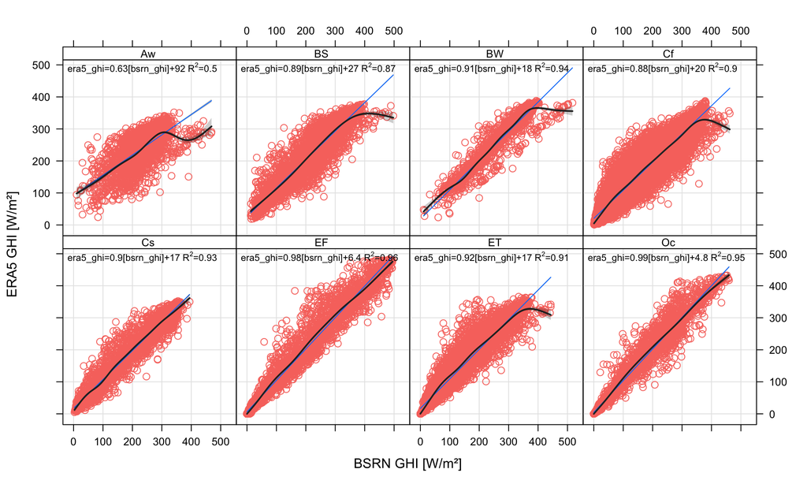

Figure 3: Matrix of scatterplots between reference dataset and the model’s estimates (W/m²) for all the stations and climate zones

```r
scatterPlot(tab, y = "era5_ghi", x = "bsrn_ghi", type = "KG", xlab = "BSRN GHI [W/m²]", ylab = "ERA5 GHI [W/m²]", linear = T, smooth = T)
```

## Variability and trend analysis

The main data set used at this stage is ERA5 monthly GHI averaged data on single levels from 1979 to present, otained from the Copernicus Climate Data Store (https://cds.climate.copernicus.eu/cdsapp#!/dataset/reanalysis-era5-single-levels-monthly-means?tab=form). The data was downloaded in GRIB format and converted to NetCDF using the CDO tool. The conversion from GRIB format involved also the transformation from the irregularly spaced latitudes to a regular Gaussian grid with an equal number of longitudes on each latitude row. The longitudes of the global regular grid were shifted from 0 to 360 to the range -180 to 180 degrees, with the help of the *sellonlatbox* function from the same CDO tool.

```
cdo -f nc -t ecmwf setgridtype,regular adaptor.mars.internal-1565286172.367593-20556-9-d39c32ec-c74b-451c-97e3-32aab88f4217.grib nc/ghi.nc
cdo sellonlatbox,-180,180,-90,90 nc/ghi.nc nc/ghi_rot_1980_2018.nc
# transform from J/m2 to W/m2
cdo aexpr,"SSRD=SSRD/(3600 * 24)"  ghi_rot_1980_2018.nc  ghi_1980_2018.nc
# compute seasonal means
cdo -v seasavg nc/ghi_1980_2018.nc nc/ghi_seasonal_1980_2018.nc
# remove first time step (incomplete 1980 DJF seasons)
cdo delete,timestep=1 nc/ghi_seasonal_1980_2018.nc nc/ghi_seasons_1981_2018.nc
```

The nonparametric Mann-Kendall trend test was employed to detect the significance of monotonic trends for each grid cell GHI data, between 1980 to 2018 (Kendall 1948; Mann 1945). The MK test is a rank-basedprocedure, especially suitable for non-normally distributed data, data containing outliersand nonlinear trends. The linear trends were computed for each season using the method of Theil and Sen (Thiel 1950; Sen 1968). The methods mentioned above are implemeted in the R library **EnvStats**, which provides a set of powerful functions for graphical and statistical analyses of environmental data (Millard 2013). The rasters with the trends computed for each season are saved as R objects in the *RData* directory of the project.

```r
library(raster, quietly = T, warn.conflicts = F)
library(EnvStats, quietly = T, warn.conflicts = F)
library(parallel, quietly = T, warn.conflicts = F)
library(ncdf4,quietly = T, warn.conflicts = F )
# function to compute Slope and p values
trend.slope <- function(y) {
  fit <- kendallTrendTest(y ~ 1)
  fit.results <- fit$estimate[2]
  fit.results <- c(fit.results, fit$p.value)
  return(fit.results)
}

# read seasonal means
r <- brick("../nc/ghi_seasons_1981_2018.nc")

mid.seasons <- c("04", "07", "10", "01")

# it takes about 20 min
for (i in 1:length(mid.seasons)) {
  # print(mid.seasons[i])
  # subset for each season
  r.seasons <- r[[which(substr(names(r),7,8) == mid.seasons[i])]]

  # compute trend in parallel (10 cores)
  beginCluster(n = 10)
  # system.time(
  ghi.trend.parallel <- clusterR(r.seasons , calc, args = list(fun = trend.slope))
  # )
  endCluster()

  names(ghi.trend.parallel) <- c("slope", "p.value")

  # write raster brick as R objects
  saveRDS(ghi.trend.parallel, file = paste0("../RData/ghi_trends_",mid.seasons[i], ".rds"))
  #plot(ghi.trend.parallel)
}
```

The maps wit the trende were ploted ussing *spplot()* function from **sp** R package (Bivand, Pebesma, and Gomez-Rubio 2013). The world country borders were obtained from the **rnaturalearth** dataset (South 2017), which contains free for use in any type of project World borders dataset available at 1:10m, 1:50m, and 1:110 million scales.

The spatial distribution of the seasonal significant trends (1981 - 2018) is presented figure 4 and briefly discussed in the following paragraph. The spatial variability of the trends in the different seasons is quite large. The positive significant trends (shades of red color palette) were computed for the Spring and the Summer for Europe, Central Africa, and for some areas in South America and the western part of the USA. Significant GHI decreasing trends (shades of blue color palette) occur all the seasons in the oceanic areas of equatorial belt, as well as in the Arctic Regions.

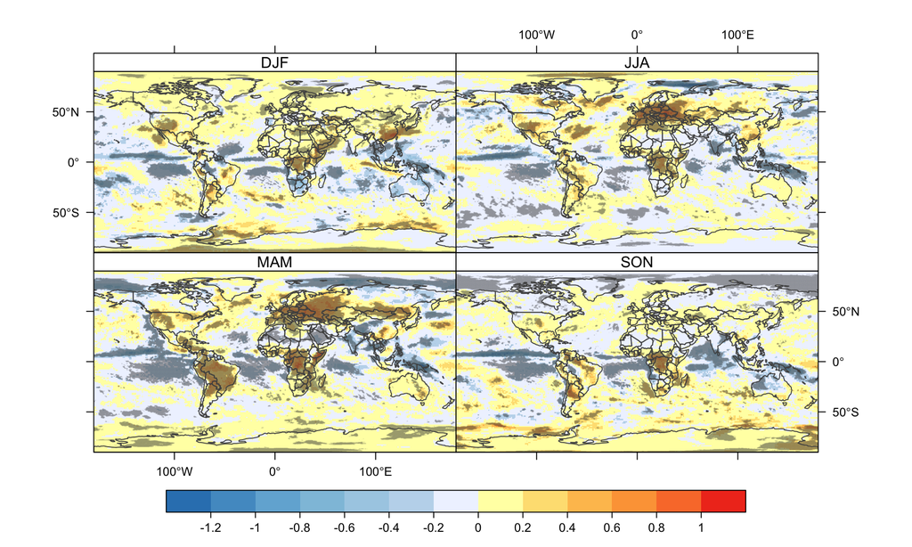

Figure 4: Trends in seasonal GHI. Gray-shaded areas in the plots highlight the grid cells presenting significant decreasing or increasing trends at 95% level (two tailed).

```r
library(raster, quietly = T, warn.conflicts = F)
library(rnaturalearth)
library(RColorBrewer)
library(lattice)


countries <- ne_countries(scale = 110, type = "countries")
countries.line <- as(countries, "SpatialLines")
countries.sp <- list("sp.lines", countries.line, col = "#525252",lwd = 1)

# compute p-values and significance levels
mk.winter <- readRDS("../RData/ghi_trends_01.rds")
p.winter <- mk.winter[[2]]
p.winter[p.winter > .05 | p.winter < -.05] <- NA
p.winter <- rasterToPoints(p.winter, spatial = T)
signif.winter <- list("sp.points", p.winter, col = "#525252",pch = 15, cex = 0.1, alpha = 0.08, which = 1)

 mk.spring <- readRDS("../RData/ghi_trends_04.rds")
p.spring <- mk.spring[[2]]
p.spring[p.spring > .05 | p.spring < -.05] <- NA
p.spring <- rasterToPoints(p.spring, spatial = T)
signif.spring <- list("sp.points", p.spring, col = "#525252",pch = 15, cex = 0.1, alpha = 0.08, which = 2)


mk.summer <- readRDS("../RData/ghi_trends_07.rds")
p.summer <- mk.summer[[2]]
p.summer[p.summer > .05 | p.summer < -.05] <- NA
p.summer <- rasterToPoints(p.summer, spatial = T)
signif.summer <- list("sp.points", p.summer, col = "#525252",pch = 15, cex = 0.1, alpha = 0.08, which = 3)


mk.fall <- readRDS("../RData/ghi_trends_10.rds")
p.fall <- mk.fall[[2]]
p.fall[p.fall > .05 | p.fall < -.05] <- NA
p.fall <- rasterToPoints(p.fall, spatial = T)
signif.fall <- list("sp.points", p.fall, col = "#525252",pch = 15, cex = 0.1, alpha = 0.08, which = 4)

signif.lists <- list(signif.winter, signif.spring, signif.summer, signif.winter)

# create raster stack with slopes for all seasons
slopes <- brick(mk.winter[[1]], mk.spring[[1]], mk.summer[[1]], mk.fall[[1]])
names(slopes) <- c("DJF", "JJA", "MAM", "SON")

# # check range of values
# summary(slopes)
brks <- seq(-1.4,1.3, 0.2)
# color pallete from red to blue
bls <- colorRampPalette(brewer.pal(6,"Blues")[1:5])
rds <- colorRampPalette(brewer.pal(6,"YlOrRd")[1:5])
cols <- c(rev(bls(8)), rds(6))

p1 <- spplot(slopes,
             sp.layout = list(countries.sp, signif.fall, signif.summer, signif.spring,signif.winter),
             scales = list(draw = TRUE, cex = 0.8),
             col.regions = cols,cuts = length(brks) - 1,at = brks,
             colorkey = list(height = 0.8,
                             labels = list(
                               at = brks[2:(length(brks) - 1)],
                               labels = round(brks,2)[2:(length(brks) - 1)]
                             ), space = "bottom"),
             par.settings = list(strip.background = list(col = "white")))

print(p1)
```

## Bibliography

Bivand, Roger S., Edzer Pebesma, and Virgilio Gomez-Rubio. 2013. *Applied Spatial Data Analysis with R, Second Edition*. Springer, NY. http://www.asdar-book.org/.

Carslaw, David C, and Karl Ropkins. 2012. “Openair—an R Package for Air Quality Data Analysis.” *Environmental Modelling & Software* 27. Elsevier: 52–61.

Hamner, B, M Frasco, and E LeDell. 2018. *Metrics: Evaluation Metrics for Machine Learning*. *R Package Version 0.1.4*. Vol. 1.

Kaspar, Frank, Uwe Schulzweida, and Ralf Muller. 2010. “Climate Data Operators as a User-Friendly Processing Tool for Cmsaf’s Satellite-Derived Climate Monitoring Products.” In *The Proc. Of the Eumetsat Meteorological Satellite Conference*.

Kendall, Maurice George. 1948. “Rank Correlation Methods.” Griffin.

Mann, Henry B. 1945. “Nonparametric Tests Against Trend.” *Econometrica: Journal of the Econometric Society*. JSTOR, 245–59.

Millard, Steven P. 2013. *EnvStats: An R Package for Environmental Statistics*. New York: Springer. http://www.springer.com.

Rubel, Franz, Katharina Brugger, Klaus Haslinger, and Ingeborg Auer. 2017. “The Climate of the European Alps: Shift of Very High Resolution Köppen-Geiger Climate Zones 1800–2100.” *Meteorologische Zeitschrift* 26 (2). Schweizerbart’sche Verlagsbuchhandlung: 115–25.

Schmithüsen, Holger, Rainer Sieger, and Gert König-Langlo. 2012. “BSRN Toolbox V2. 0–a Tool to Create Quality Checked Output Files from Bsrn Datasets and Station-to-Archive Files.” PANGAEA.

Sen, Pranab Kumar. 1968. “Estimates of the Regression Coefficient Based on Kendall’s Tau.” *Journal of the American Statistical Association* 63 (324). Taylor & Francis Group: 1379–89.

South, Andy. 2017. *Rnaturalearth: World Map Data from Natural Earth*. https://CRAN.R-project.org/package=rnaturalearth.

Thiel, H. 1950. “A Rank-Invariant Method of Linear and Polynomial Regression Analysis, Part 3.” In *Proceedings of Koninalijke Nederlandse Akademie van Weinenschatpen a*, 53:1397–1412.